# Solution to Exercise 6.1

### 02409 Multivariate Statistics

`Week F`

The data in this exercise is the well-known Iris flower data set. “The Iris flower data set or Fisher’s Iris data set is a multivariate data set introduced by Sir Ronald Fisher (1936) as an example of discriminant analysis. It is sometimes called Anderson’s Iris data set because Edgar Anderson collected the data to quantify the morphologic variation of Iris flowers of three related species. Two of the three species were collected in the Gaspé Peninsula”all from the same pasture, and picked on the same day and measured at the same time by the same person with the same apparatus”. The data set consists of 50 samples from each of three species of Iris (Iris setosa, Iris virginica and Iris versicolor). Four features were measured from each sample: the length and the width of the sepals and petals, in centimeters. Based on the combination of these four features, Fisher developed a linear discriminant model to distinguish the species from each other.” (from Wikipedia).

Below follows a sample program for discriminant analysis on the data set.

```r
Iris <- data.frame("sepallength" = c(7.9,7.7,7.7,7.7,7.7,7.6,7.4,7.3,7.2,7.2,7.2,7.1,7.0,6.9,6.9,6.9,6.9,6.8,6.8,6.8,6.7,6.7,6.7,6.7,6.7,6.7,6.7,6.7,6.6,6.6,6.5,6.5,6.5,6.5,6.5,6.4,6.4,6.4,6.4,6.4,6.4,6.4,6.3,6.3,6.3,6.3,6.3,6.3,6.3,6.3,
                                    6.3,6.2,6.2,6.2,6.2,6.1,6.1,6.1,6.1,6.1,6.1,6.0,6.0,6.0,6.0,6.0,6.0,5.9,5.9,5.9,5.8,5.8,5.8,5.8,5.8,5.8,5.8,5.7,5.7,5.7,5.7,5.7,5.7,5.7,5.7,5.6,5.6,5.6,5.6,5.6,5.6,5.5,5.5,5.5,5.5,5.5,5.5,5.5,5.4,5.4,
                                    5.4,5.4,5.4,5.4,5.3,5.2,5.2,5.2,5.2,5.1,5.1,5.1,5.1,5.1,5.1,5.1,5.1,5.1,5.0,5.0,5.0,5.0,5.0,5.0,5.0,5.0,5.0,5.0,4.9,4.9,4.9,4.9,4.9,4.9,4.8,4.8,4.8,4.8,4.8,4.7,4.7,4.6,4.6,4.6,4.6,4.5,4.4,4.4,4.4,4.3),
                   "sepalwidth" = c(3.8,3.8,2.6,2.8,3.0,3.0,2.8,2.9,3.6,3.2,3.0,3.0,3.2,3.1,3.2,3.1,3.1,2.8,3.0,3.2,3.1,3.0,3.1,2.5,3.3,3.1,3.3,3.0,2.9,3.0,2.8,3.0,3.2,3.0,3.0,3.2,2.9,2.7,3.2,2.8,2.8,3.1,3.3,2.5,2.3,3.3,2.9,2.7,2.8,3.4,
                                   2.5,2.2,2.9,2.8,3.4,2.9,2.8,2.8,3.0,3.0,2.6,2.2,2.9,2.7,3.4,2.2,3.0,3.0,3.2,3.0,4.0,2.7,2.7,2.6,2.7,2.8,2.7,4.4,3.8,2.8,2.6,3.0,2.9,2.8,2.5,2.9,3.0,2.5,3.0,2.7,2.8,4.2,3.5,2.3,2.4,2.4,2.5,2.6,3.9,3.7,
                                   3.9,3.4,3.4,3.0,3.7,3.5,3.4,4.1,2.7,3.5,3.5,3.8,3.7,3.3,3.4,3.8,3.8,2.5,3.6,3.4,3.0,3.4,3.2,3.5,3.5,3.3,2.0,2.3,3.0,3.1,3.1,3.6,2.4,2.5,3.4,3.0,3.4,3.1,3.0,3.2,3.2,3.1,3.4,3.6,3.2,2.3,2.9,3.0,3.2,3.0),
                   "petallength" = c(6.4,6.7,6.9,6.7,6.1,6.6,6.1,6.3,6.1,6.0,5.8,5.9,4.7,4.9,5.7,5.4,5.1,4.8,5.5,5.9,4.4,5.0,4.7,5.8,5.7,5.6,5.7,5.2,4.6,4.4,4.6,5.8,5.1,5.5,5.2,4.5,4.3,5.3,5.3,5.6,5.6,5.5,4.7,4.9,4.4,6.0,5.6,4.9,5.1,5.6,
                                    5.0,4.5,4.3,4.8,5.4,4.7,4.0,4.7,4.6,4.9,5.6,4.0,4.5,5.1,4.5,5.0,4.8,4.2,4.8,5.1,1.2,4.1,3.9,4.0,5.1,5.1,5.1,1.5,1.7,4.5,3.5,4.2,4.2,4.1,5.0,3.6,4.5,3.9,4.1,4.2,4.9,1.4,1.3,4.0,3.8,3.7,4.0,4.4,1.7,1.5,
                                    1.3,1.7,1.5,4.5,1.5,1.5,1.4,1.5,3.9,1.4,1.4,1.5,1.5,1.7,1.5,1.9,1.6,3.0,1.4,1.5,1.6,1.6,1.2,1.3,1.6,1.4,3.5,3.3,1.4,1.5,1.5,1.4,3.3,4.5,1.6,1.4,1.9,1.6,1.4,1.3,1.6,1.5,1.4,1.0,1.4,1.3,1.4,1.3,1.3,1.1),
                   "petalwidth" = c(2.0,2.2,2.3,2.0,2.3,2.1,1.9,1.8,2.5,1.8,1.6,2.1,1.4,1.5,2.3,2.1,2.3,1.4,2.1,2.3,1.4,1.7,1.5,1.8,2.1,2.4,2.5,2.3,1.3,1.4,1.5,2.2,2.0,1.8,2.0,1.5,1.3,1.9,2.3,2.1,2.2,1.8,1.6,1.5,1.3,2.5,1.8,1.8,1.5,2.4,
                                   1.9,1.5,1.3,1.8,2.3,1.4,1.3,1.2,1.4,1.8,1.4,1.0,1.5,1.6,1.6,1.5,1.8,1.5,1.8,1.8,0.2,1.0,1.2,1.2,1.9,2.4,1.9,0.4,0.3,1.3,1.0,1.2,1.3,1.3,2.0,1.3,1.5,1.1,1.3,1.3,2.0,0.2,0.2,1.3,1.1,1.0,1.3,1.2,0.4,0.2,
                                   0.4,0.2,0.4,1.5,0.2,0.2,0.2,0.1,1.4,0.2,0.3,0.3,0.4,0.5,0.2,0.4,0.2,1.1,0.2,0.2,0.2,0.4,0.2,0.3,0.6,0.2,1.0,1.0,0.2,0.1,0.2,0.1,1.0,1.7,0.2,0.1,0.2,0.2,0.3,0.2,0.2,0.2,0.3,0.2,0.2,0.3,0.2,0.2,0.2,0.1),
                   "species" = c("virginica","virginica","virginica","virginica","virginica","virginica","virginica","virginica","virginica","virginica","virginica","virginica","versicolor","versicolor","virginica","virginica","virginica","versicolor","virginica","virginica","versicolor","versicolor","versicolor","virginica","virginica","virginica","virginica","virginica","versicolor","versicolor","versicolor","virginica","virginica","virginica","virginica","versicolor","versicolor","virginica","virginica","virginica","virginica","virginica","versicolor","versicolor","versicolor","virginica","virginica","virginica","virginica","virginica","virginica","versicolor","versicolor","virginica","virginica","versicolor","versicolor","versicolor","versicolor","virginica","virginica","versicolor","versicolor","versicolor","versicolor","virginica","virginica","versicolor","versicolor","virginica","setosa","versicolor","versicolor","versicolor","virginica","virginica","virginica","setosa","setosa","versicolor","versicolor","versicolor","versicolor","versicolor","virginica","versicolor","versicolor","versicolor","versicolor","versicolor","virginica","setosa","setosa","versicolor","versicolor","versicolor","versicolor","versicolor","setosa","setosa","setosa","setosa","setosa","versicolor","setosa","setosa","setosa","setosa","versicolor","setosa","setosa","setosa","setosa","setosa","setosa","setosa","setosa","versicolor","setosa","setosa","setosa","setosa","setosa","setosa","setosa","setosa","versicolor","versicolor","setosa","setosa","setosa","setosa","versicolor","virginica","setosa","setosa","setosa","setosa","setosa","setosa","setosa","setosa","setosa","setosa","setosa","setosa","setosa","setosa","setosa","setosa"))

Iris$species <- as.factor(Iris$species)
```

**1. Familiarize yourself with the output from running `lda()` from the `MASS` library.**

The main purpose with exercise 6.1 is to become acquainted with the outputs from `lda()` and how to use them.

```r
# Prior probabilities fo the classes
# For setosa | versicolor | virginica :
prior=c(0.2,0.5,0.3)

#linear discriminant analysis
# ~. means all variables are included
z <- lda(species~., data = Iris, prior=prior)

Class_Level_Information = data.frame("Frequency" = z$counts,"Proportion"=z$counts/z$N,"Prior"=z$prior)
print("Class Level Information:")
Class_Level_Information
```

```
## [1] "Class Level Information:"
```

```
##            Frequency Proportion Prior
## setosa            50  0.3333333   0.2
## versicolor        50  0.3333333   0.5
## virginica         50  0.3333333   0.3
```

We get the sample size, the dimensionality of our data, the number of classes. We note how there is a difference between the proportion of the species in the data and their prior probability.

```r
n <- nrow(Iris)
Classes <- nlevels(Iris$species)

paste0("DF Within Classes = ",n-Classes)
paste0("DF Between Classes = ",Classes-1)
```

```
## [1] "DF Within Classes = 147"
```

```
## [1] "DF Between Classes = 2"
```

**DF Within Classes** is the degrees of freedom for the pooled dispersion matrix, which is **Total Sample Size - Classes** ($N-k$). **DF Between Classes** is classes minus 1 ($k-1$), and total is their sum (typical outputs from SAS).

```r
pcov <- pooled.cov(as.matrix(Iris[,c(1:4)]),Iris$species)
Det <- determinant(pcov)
print("Natural Log of the Determinant of the Covariance Matrix:")
Det$modulus[1]
# Therefore the gen.var. is:
print("gen.var.:")
exp(Det$modulus[1])
```

```
## [1] "Natural Log of the Determinant of the Covariance Matrix:"
```

```
## [1] -9.958539
```

```
## [1] "gen.var.:"
```

```
## [1] 4.732183e-05
```

We remember definition 2.4 in the book: the generalized variance of X is the determinant of the dispersion matrix. RStudio has taken the natural log of the determinant, the gen.var is thus $e^{(-9.95854)} = 4.7322 \times 10^{-5}$, which is exactly equal to the determinant of the pooled covariance matrix (you can try it out).

The next output is the squared Mahalanobis distances between the three Iris types. The values in the first are adjusted with -2 times the logarithms of the prior probabilities as explained in the section below.

```r
Means <- as.matrix(z$means)
invCov <- solve(pcov)

maha <- matrix(c(rep(0,9)),ncol=3)
mahabis <- matrix(c(rep(0,9)),ncol=3)
for (i in c(1:3)){
  for (j in c(1:3)){
    mu <- Means[i,] - Means[j,]
    maha[i,j] <- t(mu)%*%invCov%*%mu
    mahabis[i,j] <- t(mu)%*%invCov%*%mu - 2*log(prior[j])
  }
}
# squared Mahalanobis distances between the 3 Iris types.
# mahabis : Assuming unequal priors
# maha    : Assuming equal priors
print("Generalized Squared Distance to species (unequal priors):")
mahabis
print("Generalized Squared Distance to species (equal priors):")
maha
```

```
## [1] "Generalized Squared Distance to species (unequal priors):"
```

```
##            [,1]      [,2]       [,3]
## [1,]   3.218876 91.250480 181.792658
## [2,]  93.083061  1.386294  19.609012
## [3,] 182.603588 18.587361   2.407946
```

```
## [1] "Generalized Squared Distance to species (equal priors):"
```

```
##           [,1]     [,2]      [,3]
## [1,]   0.00000 89.86419 179.38471
## [2,]  89.86419  0.00000  17.20107
## [3,] 179.38471 17.20107   0.00000
```

**The Squared Generalized Distance (Definition 5.15)**

For *i = 1,…,k* we consider the populations
$$\small{\pi_{i} \leftrightarrow N(\mathbf{\mu_{i},\Sigma_{i}})},$$
with prior probabilities $p_{i}$, and observations
$$\small{X_{i1},\cdots,X_{in}}$$

We have the following estimates of means and dispersion matrices:
$$\begin{aligned}
&\widehat{{\mu}}_{i}=\frac{1}{n_{i}} \sum_{j=1}^{n_{i}} {X}_{i j} \\
&\widehat{{\Sigma}}_{i}=\frac{1}{n_{i}-1}
\sum_{j=1}^{n_{i}}\left({X}_{i j}-\overline{{X}}_{i}\right)\left({X}_{i
j}-\overline{{X}}_{i}\right)^{\prime}
\end{aligned}$$
and with $N=\sum n_{i}$ the **pooled estimate** of the dispersion matrix
$$\widehat{{\Sigma}}=\frac{1}{N-k} \sum_{i=1}^{k}\left(n_{i}-1\right)
\widehat{{\Sigma}}_{i}=\frac{1}{N-k} \sum_{i=1}^{k}
\sum_{j=1}^{n_{i}}\left({X}_{i j}-\overline{{X}}_{i}\right)\left({X}_{i
j}-\overline{{X}}_{i}\right)^{\prime}$$
If we assume that the hypothesis $H_{0}: {\Sigma}_{1}=\cdots={\Sigma}_{k}$ is true, we define the squared generalized distance from $\widehat{\mu}_{j}$ to population $\pi_{i}$ as $D_{i}^{2}\left(\widehat{{\mu}}_{j}\right)= \begin{cases}\left(\widehat{{\mu}}_{i}-\widehat{{\mu}}_{j}\right)^{\prime} \widehat{{\Sigma}}^{-1}\left(\widehat{{\mu}}_{i}-\widehat{{\mu}}_{j}\right) & \text { if the priors are equal } \\ \left(\widehat{{\mu}}_{i}-\widehat{{\mu}}_{j}\right)^{\prime} \widehat{{\Sigma}}^{-1}\left(\widehat{{\mu}}_{i}-\widehat{{\mu}}_{j}\right)-2 \ln p_{i} & \text { if the priors are not all equal }\end{cases}$
If the hypothesis is not true,we define the squared generalized distance from $\widehat{\mu}_{j}$ to population $\pi_{i}$ as
$D_{i}^{2}\left(\widehat{{\mu}}_{j}\right)= \begin{cases}\left(\widehat{{\mu}}_{i}-\widehat{{\mu}}_{j}\right)^{\prime} \widehat{{\Sigma}}_{i}^{-1}\left(\widehat{{\mu}}_{i}-\widehat{{\mu}}_{j}\right)+\ln \left|\widehat{{\Sigma}}_{i}\right| & \text { if the priors are equal } \\ \left(\widehat{{\mu}}_{i}-\widehat{{\mu}}_{j}\right)^{\prime} \widehat{{\Sigma}}_{i}^{-1}\left(\widehat{{\mu}}_{i}-\widehat{{\mu}}_{j}\right)+\ln \left|\widehat{{\Sigma}}_{i}\right|-2 \ln p_{i} & \text { if the priors are not all equal }\end{cases}$

We see that the of those 4 expressions is equal to the squared Mahalanobis distance between populations $\pi_{i}$ and $\pi_{j}$.

Note also that this is the only case where the squared generalized distance is symmetric in *i* and *j*.

```r
zpred <- predict(z)

#Confusion Matrix:
print("Confusion Matrix:")
xtabs(~Iris$species+zpred$class)

#Class Error Rates:
Er_Setosa = 1 - sum(zpred$class == 'setosa' & Iris$species == 'setosa')/50
Er_Versi = 1 - sum(zpred$class == 'versicolor' & Iris$species == 'versicolor')/50
Er_Virgin = 1 - sum(zpred$class == 'virginica' & Iris$species == 'virginica')/50

# Error count estimates for species

print("Error Rate:")
c(Er_Setosa,Er_Versi,Er_Virgin)
print("Priors:")
prior
```

```
## [1] "Confusion Matrix:"
```

```
##             zpred$class
## Iris$species setosa versicolor virginica
##   setosa         50          0         0
##   versicolor      0         48         2
##   virginica       0          1        49
```

```
## [1] "Error Rate:"
```

```
## [1] 0.00 0.04 0.02
```

```
## [1] "Priors:"
```

```
## [1] 0.2 0.5 0.3
```

The above is a confusion matrix (see section 5.3.1 and section 5.3.2 in the book) with the prior probabilities appended.

The *‘Class error rate’* or *‘Missclassification rate’* Table 5.3 section 5.3.1. For example for ‘Versicolor’ we have a *Class error rate* = $1 - \frac{N_{i i}}{N_{i .}}$ = $1 - \frac{48}{50}$ = $0.04$.

**2. Do some experiments with different parameters and evaluate the consequences. Try to alter some of the priors. Try fewer variables (use `species ~ petallength + sepalwidth` in `lda()`).**

We try changing the priors:

```r
# For setosa | versicolor | virginica :
prior1=c(0.1,0.8,0.1)

z1 <- lda(species~., data = Iris, prior=prior1)
zpred1 <- predict(z1)

#Confusion matrix:
print("Confusion Matrix:")
xtabs(~Iris$species+zpred1$class)

Er_Setosa1 = 1 - sum(zpred1$class == 'setosa' & Iris$species == 'setosa')/50
Er_Versi1 = 1 - sum(zpred1$class == 'versicolor' & Iris$species == 'versicolor')/50
Er_Virgin1 = 1 - sum(zpred1$class == 'virginica' & Iris$species == 'virginica')/50
print("Error Rate:")
c(Er_Setosa1,Er_Versi1,Er_Virgin1)
print("Priors:")
prior1
```

```
## [1] "Confusion Matrix:"
```

```
##             zpred1$class
## Iris$species setosa versicolor virginica
##   setosa         50          0         0
##   versicolor      0         50         0
##   virginica       0          5        45
```

```
## [1] "Error Rate:"
```

```
## [1] 0.0 0.0 0.1
```

```
## [1] "Priors:"
```

```
## [1] 0.1 0.8 0.1
```

By putting a large prior probability on versicolor, we have made that class more probable and we get 55 samples classified as versicolor vs. 49 before.

If we try with only two variables:

```r
# trying with different amounts of variables
prior=c(0.2,0.5,0.3)

z2var <- lda(species ~ petallength + sepalwidth, data = Iris, prior=prior)
zpred2 <- predict(z2var)

#Confusion matrix:
print("Confusion Matrix:")
xtabs(~Iris$species+zpred2$class)


#Class Error Rates:
Er_Setosa2 = 1 - sum(zpred2$class == 'setosa' & Iris$species == 'setosa')/50
Er_Versi2 = 1 - sum(zpred2$class == 'versicolor' & Iris$species == 'versicolor')/50
Er_Virgin2 = 1 - sum(zpred2$class == 'virginica' & Iris$species == 'virginica')/50
print("Error Rate:")
c(Er_Setosa2,Er_Versi2,Er_Virgin2)
print("Priors:")
prior
```

```
## [1] "Confusion Matrix:"
```

```
##             zpred2$class
## Iris$species setosa versicolor virginica
##   setosa         50          0         0
##   versicolor      0         48         2
##   virginica       0          6        44
```

```
## [1] "Error Rate:"
```

```
## [1] 0.00 0.04 0.12
```

```
## [1] "Priors:"
```

```
## [1] 0.2 0.5 0.3
```

We notice that the misclassifications have increased from 3 to 8. This is not strange as we have less information to classify with!

We will now compute the pooled covariance for each species (and with all variables), which corresponds to the pool=test in SAS:

```r
# Equivalent of pooled=test
# Doing pooled covariance for each species
within_cov = c()
for (i in c('setosa','versicolor','virginica')){
  pcov2 = data.frame(Iris[Iris$species==i,])
  pcovSet = pooled.cov(as.matrix(pcov2[,c(1:4)]),c(rep(1,50)))
  det = determinant(pcovSet)
  within_cov[i] = det$modulus[1]
}
within_cov["Pooled"] = Det$modulus[1]
print("Natural Log of the Determinant of the Covariance Matrix:")
within_cov
```

```
## [1] "Natural Log of the Determinant of the Covariance Matrix:"
```

```
##     setosa versicolor  virginica     Pooled
## -13.067360 -10.874325  -8.927058  -9.958539
```

This seems to indicate some differences in the dispersion matrices. A test for this is the Test of Homogeneity of Within Covariance Matrices, which is an output in SAS, and is computed with the `box_m()` function:

```r
# Test of Homogeneity of Within Covariance Matrices
# Morrison D.F. (1976) Multivariate Statistical Methods p.252.
# See theorem 4.32 chisq value.
box_m(Iris[,-5],Iris[,5])
```

```
## # A tibble: 1 × 4
##   statistic  p.value parameter method
##       <dbl>    <dbl>     <dbl> <chr>
## 1      141. 3.35e-20        20 Box's M-test for Homogeneity of Covariance Matri…
```

> Since the Chi-Square value is significant at the 0.1 level, the within covariance matrices will be used in the discriminant function.

> Reference: Morrison, D.F. (1976) Multivariate Statistical Methods p252.

I.e we strongly reject the hypothesis that the dispersion is equal across the species! This leads us to use different dispersion for each class, which mean that we will use a Quadratic Discriminant Analysis. The same as if we had specified pool =no in SAS.

The number Chi-Square is calculated from the Natural Log of the Determinant of the Covariance Matrix numbers, see theorem 4.32 in the book.

*When evaluating the classifiers, then classifying the same observations that were used for “training” is not optimal. Therefore we generate two other datasets, `iriscali` and `iristest` so that one may “train” on one set and “classify” the other.*

**3. Evaluate the outcome of this procedure. Try to change the sizes of `iriscali` and `iristest` by changing the threshold in the random number generator.**

We run the selection:

```r
# using a seed to always get the same training and testing sample:
set.seed(8)
sample_size = 0.6*nrow(Iris)

samp  = sample(seq_len(nrow(Iris)),size = sample_size)
iriscali = Iris[samp,]
iristest  = Iris[-samp,]

# lda with training subset, and predicting on the test subset
DISCRIM_train <- lda(species ~., data = iriscali,prior = c(1/3,1/3,1/3)) # assume equal priors

predi_test = predict(DISCRIM_train,iristest)
split = table(predi_test$class)
```

The data is split such that we will have 60% of our data in the training set and 40% in the test set. `set.seed()` provides a way of always getting the same sequence generation created by `seq_len()`.

We look at the confusion matrix:

```r
# comparing the predicted classes to real classes
predictions_test <- predi_test$class
values_test<-iristest$species

#Confusion matrix:
print("Confusion Matrix:")
xtabs(~iristest$species+predi_test$class)

Er_Setosa_test = 1 - sum(predi_test$class == 'setosa' & iristest$species == 'setosa')/split[1]
Er_Versi_test = 1 - sum(predi_test$class == 'versicolor' & iristest$species == 'versicolor')/split[2]
Er_Virgin_test = 1 - sum(predi_test$class == 'virginica' & iristest$species == 'virginica')/split[3]
print("Error Rate:")
c(Er_Setosa_test,Er_Versi_test,Er_Virgin_test)

print("Error Rate derived earlier:")
c(Er_Setosa,Er_Versi,Er_Virgin)
```

```
## [1] "Confusion Matrix:"
```

```
##                 predi_test$class
## iristest$species setosa versicolor virginica
##       setosa         18          0         0
##       versicolor      0         21         1
##       virginica       0          1        19
```

```
## [1] "Error Rate:"
```

```
##     setosa versicolor  virginica
## 0.00000000 0.04545455 0.05000000
```

```
## [1] "Error Rate derived earlier:"
```

```
## [1] 0.00 0.04 0.02
```

We note how the number of misclassifications has decreased compared to the situation where we train and test on the full dataset; but since the test set is smaller, this is not the correct measure to use. Instead we consider the misclassification rates.

It is thus apparent that, that using the same data for both training and testing yields too optimistic results. However, we have less confident estimates of our mean and dispersion matrices - and thus discriminant functions - since we have less data to train on. In practice, this means that we can only partition the data into a test and training set in data rich situations. Often we have to rely on cross validation or bootstrapping instead.

For crossvalidation we can use the ‘leave one out’ method. This measure has a low bias, i.e. it is on average close to the true prediction error, but it has a large variance, i.e. for a specific application we cannot be sure that it has estimated the true prediction error. As a compromise 5 to 10 fold cross validation is recommended. These are pessimistic, i.e. the estimated prediction error is worse than the true and the variance is smaller than for ‘leave one out’.

**4. Compare the plot of the canonical discriminant function variables and the sepal variables.**

We have 4 variables and we thus have 6 different ways of plotting the data in a 2D space using the original variables. We can try different combinations, but here we just look at the sepal variables.

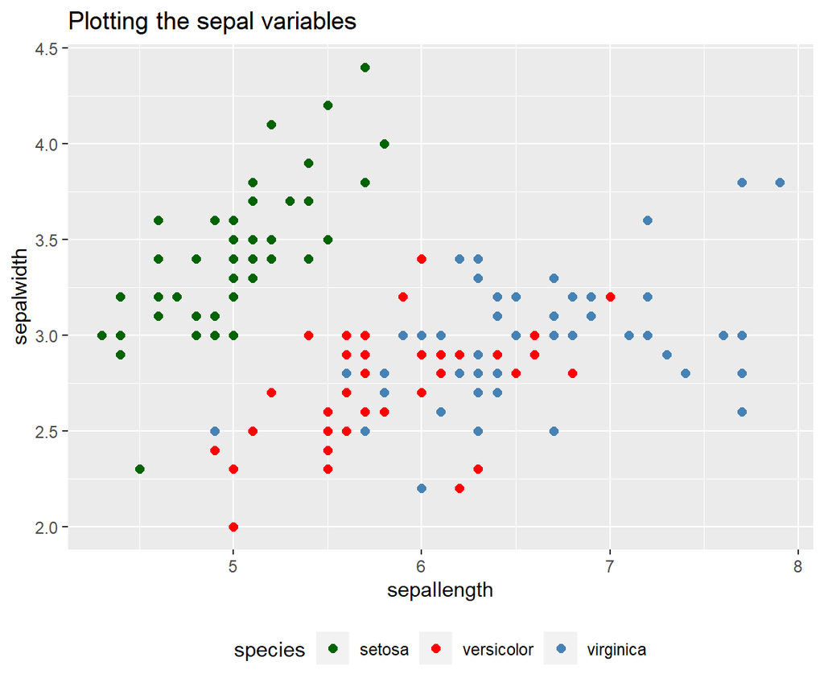

```r
ggplot(Iris,aes(x = sepallength,y = sepalwidth,color=species))+
  geom_point(size = 2)+
  scale_color_manual(values = c("setosa" = "darkgreen",
                                "versicolor"="red",
                                "virginica"="steelblue"))+
  ggtitle('Plotting the sepal variables')+
  theme(legend.position = "bottom")
```

It is clear that a discrimination between the groups will be difficult if not impossible here, as ‘virginica’ and ‘versicolor’ is mixed.

If we instead use the canonical variables and plot those, we get:

**Note: For consistency of description between the output in SAS and in R, LD1 is multiplied by -1 to have the same plots in both solutions.**

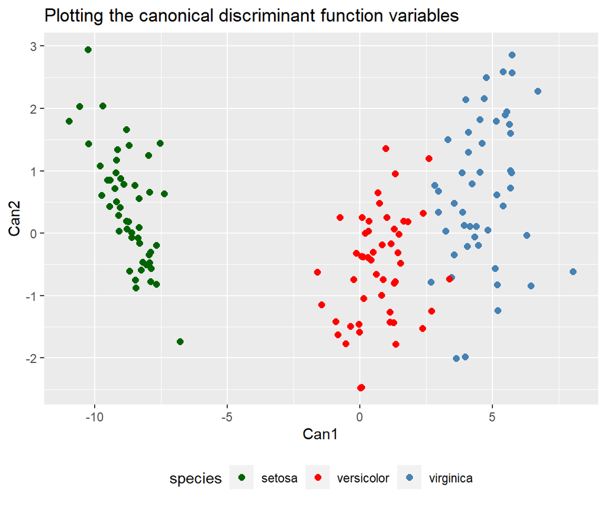

```r
#add the LD1,LD2 to the other columns of Iris dataset.
lda_plot = cbind(Iris,zpred$x)

ggplot(lda_plot,aes(-1*LD1,LD2,color=species))+
  geom_point(size = 2)+
  scale_color_manual(values = c("setosa" = "darkgreen",
                                "versicolor"="red",
                                "virginica"="steelblue"))+
  ggtitle('Plotting the canonical discriminant function variables')+
  xlab("Can1")+ylab("Can2")+
  theme(legend.position = "bottom")
```

We now have the best possible (groups-1)D - in this case 2D - representation for discrimination. Canonical discriminant functions are thus a way for projecting the data into a lower dimensional space, while maximizing the between group variance. Canonical Discriminant Analysis summarizes between groups variation like PCA summarizes variance.

The first canonical variable summarizes most of the between group variation, which is also apparent in the figure.